# Lab03

```
Data Mining
Lab - 3
¥@$# Kakadiya | 23010101121 | 18/6/2025
```

### 1) First, you need to read the titanic dataset from local disk and display first five records

```python
import pandas as pd
import numpy as np
import matplotlib.pyplot as plt
```

```python
df=pd.read_csv('../data/titanic.csv')
```

```python
df.head(5)
```

|  | PassengerId | Survived | Pclass | Name | Sex | Age | SibSp | Parch | Ticket | Fare | Cabin | Embarked |
| --- | --- | --- | --- | --- | --- | --- | --- | --- | --- | --- | --- | --- |
| 0 | 1 | 0 | 3 | Braund, Mr. Owen Harris | male | 22.0 | 1 | 0 | A/5 21171 | 7.2500 | NaN | S |
| 1 | 2 | 1 | 1 | Cumings, Mrs. John Bradley (Florence Briggs Th... | female | 38.0 | 1 | 0 | PC 17599 | 71.2833 | C85 | C |
| 2 | 3 | 1 | 3 | Heikkinen, Miss. Laina | female | 26.0 | 0 | 0 | STON/O2. 3101282 | 7.9250 | NaN | S |
| 3 | 4 | 1 | 1 | Futrelle, Mrs. Jacques Heath (Lily May Peel) | female | 35.0 | 1 | 0 | 113803 | 53.1000 | C123 | S |
| 4 | 5 | 0 | 3 | Allen, Mr. William Henry | male | 35.0 | 0 | 0 | 373450 | 8.0500 | NaN | S |

### 2) Identify Nominal, Ordinal, Binary and Numeric attributes from data sets and display all values.

```python
nominal=['Name','Ticket','Cabin']
ordinal=['Pclass','Embarked']
binary=['Survived','Sex']
numeric=['PassengerId','Fare','SibSp','Age','Parch']
print('Nominal:',nominal)
print('Ordinal:',ordinal)
print('Binary:',binary)
print('Numeric:',numeric)
```

```
Nominal: ['Name', 'Ticket', 'Cabin']
Ordinal: ['Pclass', 'Embarked']
Binary: ['Survived', 'Sex']
Numeric: ['PassengerId', 'Fare', 'SibSp', 'Age', 'Parch']
```

### 3) Identify symmetric and asymmetric binary attributes from data sets and display all values.

```python
symmetric=['Sex']
asymmetric=['Survived']
print('Symmetric:\n',df['Sex'].value_counts())
print('Asymmetric:\n',df['Survived'].value_counts())
```

```
Symmetric:
 Sex
male      577
female    314
Name: count, dtype: int64
Asymmetric:
 Survived
0    549
1    342
Name: count, dtype: int64
```

### 4) For each quantitative attribute, calculate its average, standard deviation, minimum, mode, range and maximum values.

```python
columns=['PassengerId','Survived','Pclass','Age','SibSp','Parch','Fare',];

for i  in columns:
    print(i,': ')
    print('\tAverage: ', df[i].mean())
    print('\tStandard deviation: ', df[i].std())
    print('\tMinimum: ', df[i].min())
    print('\tMode: ', df[i].mode()[0])
    print('\tRange: ', df[i].max()-df[i].min())
    print('\tMax: ', df[i].max())
    print('-----------------------------------------------')
```

```
PassengerId :
	Average:  446.0
	Standard deviation:  257.3538420152301
	Minimum:  1
	Mode:  1
	Range:  890
	Max:  891
-----------------------------------------------
Survived :
	Average:  0.3838383838383838
	Standard deviation:  0.4865924542648585
	Minimum:  0
	Mode:  0
	Range:  1
	Max:  1
-----------------------------------------------
Pclass :
	Average:  2.308641975308642
	Standard deviation:  0.8360712409770513
	Minimum:  1
	Mode:  3
	Range:  2
	Max:  3
-----------------------------------------------
Age :
	Average:  29.69911764705882
	Standard deviation:  14.526497332334044
	Minimum:  0.42
	Mode:  24.0
	Range:  79.58
	Max:  80.0
-----------------------------------------------
SibSp :
	Average:  0.5230078563411896
	Standard deviation:  1.1027434322934275
	Minimum:  0
	Mode:  0
	Range:  8
	Max:  8
-----------------------------------------------
Parch :
	Average:  0.38159371492704824
	Standard deviation:  0.8060572211299559
	Minimum:  0
	Mode:  0
	Range:  6
	Max:  6
-----------------------------------------------
Fare :
	Average:  32.204207968574636
	Standard deviation:  49.693428597180905
	Minimum:  0.0
	Mode:  8.05
	Range:  512.3292
	Max:  512.3292
-----------------------------------------------
```

### 6) For the qualitative attribute (class), count the frequency for each of its distinct values.

```python
qualitative_attributes=['Pclass','Name','Ticket','Cabin','Embarked','Sex']
for i in qualitative_attributes:
    print(df[i].value_counts())
    print('---------------------------------------------')
```

```
Pclass
3    491
1    216
2    184
Name: count, dtype: int64
---------------------------------------------
Name
Braund, Mr. Owen Harris                     1
Boulos, Mr. Hanna                           1
Frolicher-Stehli, Mr. Maxmillian            1
Gilinski, Mr. Eliezer                       1
Murdlin, Mr. Joseph                         1
                                           ..
Kelly, Miss. Anna Katherine "Annie Kate"    1
McCoy, Mr. Bernard                          1
Johnson, Mr. William Cahoone Jr             1
Keane, Miss. Nora A                         1
Dooley, Mr. Patrick                         1
Name: count, Length: 891, dtype: int64
---------------------------------------------
Ticket
347082      7
CA. 2343    7
1601        7
3101295     6
CA 2144     6
           ..
9234        1
19988       1
2693        1
PC 17612    1
370376      1
Name: count, Length: 681, dtype: int64
---------------------------------------------
Cabin
B96 B98        4
G6             4
C23 C25 C27    4
C22 C26        3
F33            3
              ..
E34            1
C7             1
C54            1
E36            1
C148           1
Name: count, Length: 147, dtype: int64
---------------------------------------------
Embarked
S    644
C    168
Q     77
Name: count, dtype: int64
---------------------------------------------
Sex
male      577
female    314
Name: count, dtype: int64
---------------------------------------------
```

### 7) It is also possible to display the summary for all the attributes simultaneously in a table using the describe() function. If an attribute is quantitative, it will display its mean, standard deviation and various quantiles (including minimum, median, and maximum) values. If an attribute is qualitative, it will display its number of unique values and the top (most frequent) values.

```python
print('Summary of numeric attributes:')
print(df.describe())
print()
print('-----------------------------------------------------------------------------')

print('Summary of all attributes:')
print(df.describe(include = 'all'))
print()
print('-----------------------------------------------------------------------------')

print('Summary of categorical attributes:')
print(df.describe(include = 'object'))
```

```
Summary of numeric attributes:
       PassengerId    Survived      Pclass         Age       SibSp  \
count   891.000000  891.000000  891.000000  714.000000  891.000000
mean    446.000000    0.383838    2.308642   29.699118    0.523008
std     257.353842    0.486592    0.836071   14.526497    1.102743
min       1.000000    0.000000    1.000000    0.420000    0.000000
25%     223.500000    0.000000    2.000000   20.125000    0.000000
50%     446.000000    0.000000    3.000000   28.000000    0.000000
75%     668.500000    1.000000    3.000000   38.000000    1.000000
max     891.000000    1.000000    3.000000   80.000000    8.000000

            Parch        Fare
count  891.000000  891.000000
mean     0.381594   32.204208
std      0.806057   49.693429
min      0.000000    0.000000
25%      0.000000    7.910400
50%      0.000000   14.454200
75%      0.000000   31.000000
max      6.000000  512.329200

-----------------------------------------------------------------------------
Summary of all attributes:
        PassengerId    Survived      Pclass                     Name   Sex  \
count    891.000000  891.000000  891.000000                      891   891
unique          NaN         NaN         NaN                      891     2
top             NaN         NaN         NaN  Braund, Mr. Owen Harris  male
freq            NaN         NaN         NaN                        1   577
mean     446.000000    0.383838    2.308642                      NaN   NaN
std      257.353842    0.486592    0.836071                      NaN   NaN
min        1.000000    0.000000    1.000000                      NaN   NaN
25%      223.500000    0.000000    2.000000                      NaN   NaN
50%      446.000000    0.000000    3.000000                      NaN   NaN
75%      668.500000    1.000000    3.000000                      NaN   NaN
max      891.000000    1.000000    3.000000                      NaN   NaN

               Age       SibSp       Parch  Ticket        Fare    Cabin  \
count   714.000000  891.000000  891.000000     891  891.000000      204
unique         NaN         NaN         NaN     681         NaN      147
top            NaN         NaN         NaN  347082         NaN  B96 B98
```

[output cut: 14 more lines]

```
mean        NaN
std         NaN
min         NaN
25%         NaN
50%         NaN
75%         NaN
max         NaN

-----------------------------------------------------------------------------
Summary of categorical attributes:
                           Name   Sex  Ticket    Cabin Embarked
count                       891   891     891      204      889
unique                      891     2     681      147        3
top     Braund, Mr. Owen Harris  male  347082  B96 B98        S
freq                          1   577       7        4      644
```

### 8) For multivariate statistics, you can compute the covariance and correlation between pairs of attributes.

```python
print('Covarinace matrix:')
df.cov(numeric_only = True)
```

```
Covarinace matrix:
```

|  | PassengerId | Survived | Pclass | Age | SibSp | Parch | Fare |
| --- | --- | --- | --- | --- | --- | --- | --- |
| PassengerId | 66231.000000 | -0.626966 | -7.561798 | 138.696504 | -16.325843 | -0.342697 | 161.883369 |
| Survived | -0.626966 | 0.236772 | -0.137703 | -0.551296 | -0.018954 | 0.032017 | 6.221787 |
| Pclass | -7.561798 | -0.137703 | 0.699015 | -4.496004 | 0.076599 | 0.012429 | -22.830196 |
| Age | 138.696504 | -0.551296 | -4.496004 | 211.019125 | -4.163334 | -2.344191 | 73.849030 |
| SibSp | -16.325843 | -0.018954 | 0.076599 | -4.163334 | 1.216043 | 0.368739 | 8.748734 |
| Parch | -0.342697 | 0.032017 | 0.012429 | -2.344191 | 0.368739 | 0.649728 | 8.661052 |
| Fare | 161.883369 | 6.221787 | -22.830196 | 73.849030 | 8.748734 | 8.661052 | 2469.436846 |

```python
print('Correlation matrix:')
df.corr(numeric_only = True)
```

```
Correlation matrix:
```

|  | PassengerId | Survived | Pclass | Age | SibSp | Parch | Fare |
| --- | --- | --- | --- | --- | --- | --- | --- |
| PassengerId | 1.000000 | -0.005007 | -0.035144 | 0.036847 | -0.057527 | -0.001652 | 0.012658 |
| Survived | -0.005007 | 1.000000 | -0.338481 | -0.077221 | -0.035322 | 0.081629 | 0.257307 |
| Pclass | -0.035144 | -0.338481 | 1.000000 | -0.369226 | 0.083081 | 0.018443 | -0.549500 |
| Age | 0.036847 | -0.077221 | -0.369226 | 1.000000 | -0.308247 | -0.189119 | 0.096067 |
| SibSp | -0.057527 | -0.035322 | 0.083081 | -0.308247 | 1.000000 | 0.414838 | 0.159651 |
| Parch | -0.001652 | 0.081629 | 0.018443 | -0.189119 | 0.414838 | 1.000000 | 0.216225 |
| Fare | 0.012658 | 0.257307 | -0.549500 | 0.096067 | 0.159651 | 0.216225 | 1.000000 |

### 9) Display the histogram for Age attribute by discretizing it into 8 separate bins and counting the frequency for each bin.

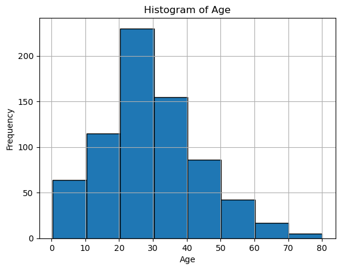

```python
df['Age'].dropna().hist(bins = 8, edgecolor = 'black', )
plt.title('Histogram of Age')
plt.xlabel('Age')
plt.ylabel('Frequency')
plt.show()
```

### 10) A boxplot can also be used to show the distribution of values for each attribute.

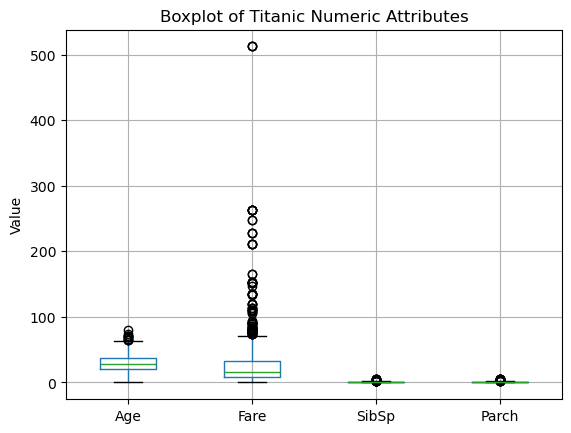

```python
numeric = ['Age', 'Fare', 'SibSp', 'Parch']
data = df[numeric].dropna()

data.boxplot(column = numeric)
plt.title("Boxplot of Titanic Numeric Attributes")
plt.ylabel("Value")
plt.grid(True)
plt.show()
```

### 11) Display scatter plot for any 5 pair of attributes , we can use a scatter plot to visualize their joint distribution.

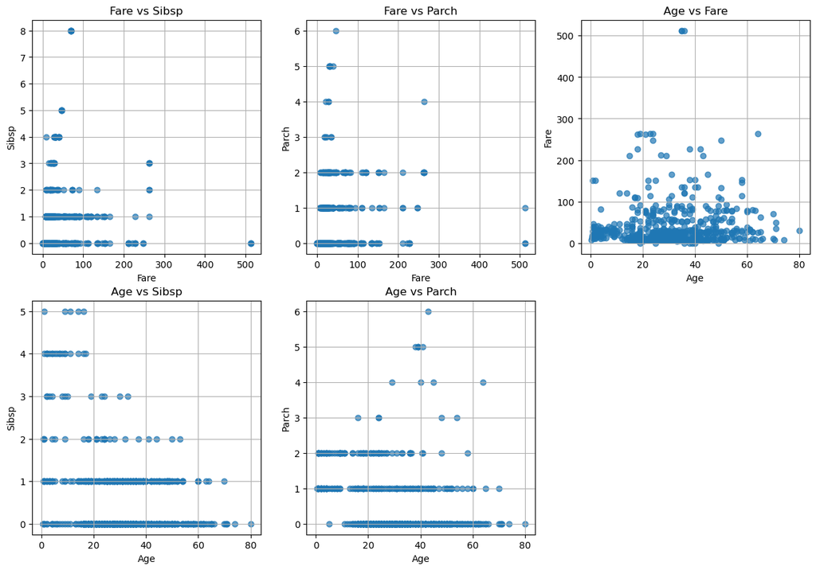

```python
pairs = [ ('Fare', 'SibSp'), ('Fare', 'Parch'),('Age', 'Fare'),('Age', 'SibSp'), ('Age', 'Parch')]

plt.figure(figsize = (15, 10))

for i, (x, y) in enumerate(pairs):
    plt.subplot(2, 3, i + 1)
    plt.scatter(df[x], df[y], alpha=0.7)
    plt.xlabel(x.capitalize())
    plt.ylabel(y.capitalize())
    plt.title(f"{x.capitalize()} vs {y.capitalize()}")
    plt.grid(True)
```